# Fundamentals in Programming

# Welcome to R for Biologists Workshop!

[figure not shown]

# Workflow

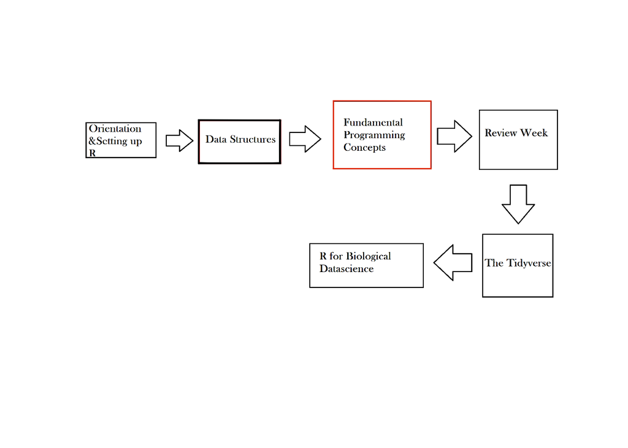

# Flow Controls

Flow controls add efficiency to your code, making it easier to read and saving you time overall

## IF statements

If a condition is TRUE then the code is performed, but if the condition is FALSE then nothing occurs

This can take the form of either a numeric or a logical vector

**Numeric**

```r
x = 42

x > 0
```

```
## [1] TRUE
```

```r
if(x>0) {
  print ("Positive number")
}
```

```
## [1] "Positive number"
```

```r
x = -42

if (x>0) {
  print("Positive number")
}
```

**Logical**

```r
x = 3

x == 3
```

```
## [1] TRUE
```

```r
if (x == 3){
  print ("X is equal to three")
}
```

```
## [1] "X is equal to three"
```

```r
if (x != 3) {
  print ("X is not equal to three")
}
```

## Else Statements

else is optional and is only evaluated if conditions to are FALSE

**Numerical**

```r
x = 42

if (x > 0) {
  print("Positive number")
} else {
  print ("Negative number")
}
```

```
## [1] "Positive number"
```

```r
y = -42

if (y > 0) {
  print("Positive number")
} else {
  print ("Negative number")
}
```

```
## [1] "Negative number"
```

**Logical condition**

```r
x = 42
if (x==3){
  print ("X is equal to three")
} else {
  print ("X does not equal to three")
}
```

```
## [1] "X does not equal to three"
```

To get even more control from your block of code, you can use else if controls…

# Else If

If you need more conditions to execute your code, then you can utilize the feature of else if flow control

```r
x = 0

if (x==3){
  print ("X is equal to three")
} else if (x == 0){
  print ("X is equal to zero")
} else {
  print ("I don't know what X is")
}
```

```
## [1] "X is equal to zero"
```

# Loops

Loops are used in programming to repeat a specific block of code. These include For loops and While loops.

## For loops

For loops iterate across a sequence of values, repeatedly running code for each value in a list or vector.

```r
numbers <- c(1,2,3,4,6)

print(numbers[1])
```

```
## [1] 1
```

```r
print(numbers[2])
```

```
## [1] 2
```

```r
print(numbers[3])
```

```
## [1] 3
```

```r
print(numbers[4])
```

```
## [1] 4
```

Whereas using the ‘for loops’ you can do the same thing but with much less effort.

```r
for (var in numbers) {
  print (var)
  }
```

```
## [1] 1
## [1] 2
## [1] 3
## [1] 4
## [1] 6
```

You can utilize index within a for loop function as well.

```r
for (var in 1:length(numbers)){
  print (numbers[var])
}
```

```
## [1] 1
## [1] 2
## [1] 3
## [1] 4
## [1] 6
```

## While loops

This type of loop continues to repeat until a specific condition is met and the condition evaluates to FALSE

```r
x <- 1

while (x<6){
  print (paste("x is equal to", x))

  x <-  x + 1
}
```

```
## [1] "x is equal to 1"
## [1] "x is equal to 2"
## [1] "x is equal to 3"
## [1] "x is equal to 4"
## [1] "x is equal to 5"
```

Notice how in the above code I made sure to correct x so that eventually x will be 6 or greater, whereby the while condition will return FALSE and end. If I didn’t do that, the while function would run forever.

# Break and Next statements

## Break Statements

Break statements are used to terminate the loop at any chosen iteration.

You can use them in both if statements and for loops

```r
numbers <- c(1,2,4,6)

for (var in numbers){
  if (var == 4){
    print (paste("The variable 4 should not be there, exiting"))
    break
  }
  print(paste("Values are : ", var))
}
```

```
## [1] "Values are :  1"
## [1] "Values are :  2"
## [1] "The variable 4 should not be there, exiting"
```

This immediately stops the function and it does not continue. However, if it does not encounter the break condition, then the code will continue through.

```r
numbers2 <- c(1,3,5,6)

for (var in numbers2){
  if (var == 4){
    print (paste("The variable 4 should not be there, exiting"))
    break
  }
  print(paste("Values are : ", var))
}
```

```
## [1] "Values are :  1"
## [1] "Values are :  3"
## [1] "Values are :  5"
## [1] "Values are :  6"
```

## Next Statements

But what if we don’t want to stop the code completely? We just want to skip over a part if it doesn’t match our conditions? Thats where ’Next" statements come in.

```r
numbers <- c(1, 2, 4, 6)

for (var in numbers) {
  if (var ==4) {
    print (paste ("The variable 4 should not be there"))
    next
  }
  print (paste("Values are: ", var))
}
```

```
## [1] "Values are:  1"
## [1] "Values are:  2"
## [1] "The variable 4 should not be there"
## [1] "Values are:  6"
```

## Challenge Question 1

What does the following give you?

```r
numbers <- c(1, 2, 4, 6)

for (var in numbers) {
  if (var ==4) {
    print (paste ("The variable 4 should not be there"))
    next
    print (paste("Values are: ", var))
  }
}
```

**Answer:**

```
## [1] "The variable 4 should not be there"
```

# Functions

Functions take an input (argument) and produces an output. R has many functions available to do bioinformatics work.

```r
numbers <-c(1, 2, 4, 6)

print (numbers)
```

```
## [1] 1 2 4 6
```

```r
str(numbers)
```

```
##  num [1:4] 1 2 4 6
```

```r
sum (numbers)
```

```
## [1] 13
```

```r
mean (numbers)
```

```
## [1] 3.25
```

## Read and write csv functions

These types of functions allow you to manipulate external files into or out of the R environment.

The **read.csv** function reads in an external table into your R environment

```r
Data.table <- read.csv("Bioinformatics.csv")
```

The **write.csv** function writes a data frame or other object into a table that can then be opened with excel or another text editor

```r
my.df <- data.frame(x = 1:5, y = 3:7)

write.csv (my.df, "Bioinformatics_data.csv")
```

### Challenge Question 2

In our previous .csv file that we had, the rows all matched together. But what happens when you read in a file that does not have matching rows/columns?

```r
C_Question2 <- read.csv("ChallengeQuestion2.csv")
```

**Answer:**

```
##    ï..Bioinfo Numbers
## 1           1       2
## 2           2       3
## 3           3       4
## 4           3       5
## 5           4       6
## 6           5       6
## 7           6       5
## 8           5       5
## 9           4       6
## 10          6       5
## 11         NA       6
## 12         NA       6
## 13         NA       7
```

# Make your own function

You can also utilize the full power of functions in R by personalizing them to your specific problem. General functions can make your code more clear, and can be easier to maintain that specific code. These can be functions assigned to variables.

**Function example**

```r
Square_It <- function (x) {
  y <-  x^2
  print(paste("The Square of", x, "is", y))
}

Square_It(5)
```

```
## [1] "The Square of 5 is 25"
```

```r
Square_It(42)
```

```
## [1] "The Square of 42 is 1764"
```

# Apply functions

Iterates the functions over elements in a list or a vector (lapply) or over a dataframe (apply). These functions are very similar to a for loop, but can be done in 1 line of code.

*3 types of apply functions*

- apply
- lapply
- sapply

## Apply

Lets say that we have our dataframe:

```
##    x y
## 1  2 1
## 2  5 2
## 3 10 3
## 4  2 4
## 5  3 5
```

and we want to calculate the mean of each individual row in that dataframe. Lets try it with a for loop.

```r
for (var in 1:nrow(my.df2)) {
  mymean= mean(as.numeric(my.df2[var,]))
  print(mymean)
}
```

```
## [1] 1.5
## [1] 3.5
## [1] 6.5
## [1] 3
## [1] 4
```

Lets try it with apply instead

```r
apply(my.df2, 1,  mean)
```

```
## [1] 1.5 3.5 6.5 3.0 4.0
```

## lapply

lapply works on vectors or lists, and outputs the results as a list.

```r
x <- sample(1:100, size = 10)
y <- sample(1:100, size = 10)
z <-  sample (1:100, size = 10)

lis <- list (x, y, z)

lis_min <- lapply(lis, min)

print(lis_min)
```

```
## [[1]]
## [1] 2
##
## [[2]]
## [1] 2
##
## [[3]]
## [1] 6
```

```r
str(lis_min)
```

```
## List of 3
##  $ : int 2
##  $ : int 2
##  $ : int 6
```

## sapply

As opposed to lapply, sapply will try to simplify the output of lapply()

Ths will try to output a simple array rather than a list.

```r
x <- sample(1:100, size = 10)
y <- sample(1:100, size = 10)
z <-  sample (1:100, size = 10)

lis <- list (x, y, z)

lis_min <- sapply(lis, min)

print (lis_min)
```

```
## [1]  2 19  2
```

```r
str(lis_min)
```

```
##  int [1:3] 2 19 2
```

# Which function

In R, the **which()** function gives you the **position** of elements

```r
geneIDs=read.csv("gene_id_to_symbol.csv")

Ensemble = c("ENSG00000121410", "ENSG00000175899","ENSG00000256069", "ENSG00000171428", "ENSG00000156006",
             "ENSG00000196136", "ENSG00000114771")
gene_symbol= c("A1BG", "A2M", "A2MP1","NAT1", "NAT2", "SERPINA3", "AADAC" )
entrez=c(1, 2, 3, 9, 10, 12, 13)

mygenes <- data.frame(entrez= entrez, gene_symbol= gene_symbol, Ensemble = Ensemble)

mygenes
```

```
##   entrez gene_symbol        Ensemble
## 1      1        A1BG ENSG00000121410
## 2      2         A2M ENSG00000175899
## 3      3       A2MP1 ENSG00000256069
## 4      9        NAT1 ENSG00000171428
## 5     10        NAT2 ENSG00000156006
## 6     12    SERPINA3 ENSG00000196136
## 7     13       AADAC ENSG00000114771
```

```r
my_which_function <- which(mygenes$Ensemble == "ENSG00000256069")

my_which_function
```

```
## [1] 3
```

How can the which function be powerful? Because, for example, you can use the output of the which function to return all the values in the row of your search.

```r
mygenessearch <- mygenes[my_which_function,]

mygenessearch
```

```
##   entrez gene_symbol        Ensemble
## 3      3       A2MP1 ENSG00000256069
```

# The End!

Homework: Practice problems, and datacamp